# NCDB Chondrosarcoma 2015

All

Jason Brant

March 16, 2018

**Note: To hide the code from this document, click the button in the upper right corner.**

# Data

Data including tumors of the head and neck was obtained from the NCBD on March 4, 2016. Cases that were included in this analysis were those with:

1. Site codes: All
2. Histology codes: 9220, 9221, 9231, 9240, 9242, 9243
3. Behavior codes: 3

Patients were excluded if they didn’t have values for either follow up or vital status.

Patients were excluded if they had surgery to a distant site using `RX_SUMM_SURG_OTH_REGDIS`. This was done to avoid confounding of different surgical procedures. We are only interested in surgery at the primary site. These distant site surgeries were being counted in the surgery/radiation sequence and thus to simplify analysis they were removed.

```
                              level Overall
  n                                 7604
  RX_SUMM_SURG_OTH_REGDIS (%) 0     7199 (94.7)
                              1       59 ( 0.8)
                              2       75 ( 1.0)
                              3        4 ( 0.1)
                              4       53 ( 0.7)
                              5        8 ( 0.1)
                              9      206 ( 2.7)
```

# Location grouping for chondrosarcoma

|  | level | Overall |
| --- | --- | --- |
| n |  | 7199 |
| SITE_GROUP (%) | Bones SF | 587 ( 8.2) |
|  | Intracranial | 68 ( 0.9) |
|  | Larynx | 269 ( 3.7) |
|  | Mandible | 37 ( 0.5) |
|  | Nasal Cavity | 42 ( 0.6) |
|  | Oral cavity/Pharynx | 23 ( 0.3) |
|  | Other | 6119 (85.0) |
|  | Paranasal Sinus | 35 ( 0.5) |
|  | Trachea | 19 ( 0.3) |

Cases with Other as site group were removed.

Race was grouped as white, black, asian, other/unknown Stage was grouped into 0, I, II, III, IV, NA_Unknown, stage 0 was removed Whether surgery was performed was based on the `REASON_FOR_NO_SURGERY` variable. The `SURGERY_YN` variable was classified as ‘Yes’, ‘No’, or ‘Unknown’.

Whether radiation was performed was based on the `REASON_FOR_NO_RADIATION` variable. The `RADIATION_YN` variable was classified as ‘Yes’, ‘No’, or ‘Unknown’.

[output not shown]

# Grouping of variables for chondrosarcoma

## Table of variables for all cases:

|  | level | Overall |
| --- | --- | --- |
| n |  | 1080 |
| FACILITY_TYPE_F (%) | Community Cancer Program | 11 ( 1.0) |
|  | Comprehensive Comm Ca Program | 150 ( 13.9) |
|  | Academic/Research Program | 567 ( 52.5) |
|  | Integrated Network Ca Program | 76 ( 7.0) |
|  | NA | 276 ( 25.6) |
| FACILITY_LOCATION_F (%) | New England | 38 ( 3.5) |
|  | Middle Atlantic | 149 ( 13.8) |
|  | South Atlantic | 148 ( 13.7) |
|  | East North Central | 129 ( 11.9) |
|  | East South Central | 42 ( 3.9) |
|  | West North Central | 76 ( 7.0) |
|  | West South Central | 67 ( 6.2) |
|  | Mountain | 43 ( 4.0) |
|  | Pacific | 112 ( 10.4) |
|  | NA | 276 ( 25.6) |
| FACILITY_GEOGRAPHY (%) | Northeast | 187 ( 17.3) |
|  | South | 215 ( 19.9) |
|  | Midwest | 247 ( 22.9) |
|  | West | 155 ( 14.4) |
|  | NA | 276 ( 25.6) |
| AGE (mean (sd)) |  | 52.03 (18.46) |
| AGE_F (%) | (0,54] | 567 ( 52.5) |
|  | (54,64] | 208 ( 19.3) |
|  | (64,74] | 190 ( 17.6) |
|  | (74,100] | 114 ( 10.6) |
|  | NA | 1 ( 0.1) |
| AGE_40 (%) | (0,40] | 288 ( 26.7) |
|  | (40,100] | 791 ( 73.2) |
|  | NA | 1 ( 0.1) |

[output cut: 225 more lines]

# Kaplan Meier Analysis

## All

```
_________________________________________________

## All
_________________________________________________
Call: survfit(formula = Surv(DX_LASTCONTACT_DEATH_MONTHS, PUF_VITAL_STATUS ==
    0) ~ All, data = data)

      n  events  median 0.95LCL 0.95UCL
   1080     197      NA     143      NA

Call: survfit(formula = Surv(DX_LASTCONTACT_DEATH_MONTHS, PUF_VITAL_STATUS ==
    0) ~ All, data = data)

 time n.risk n.event survival std.err lower 95% CI upper 95% CI
   12    971      52    0.950 0.00669        0.937        0.964
   24    869      30    0.920 0.00845        0.904        0.937
   36    724      20    0.898 0.00964        0.879        0.917
   48    609      25    0.865 0.01130        0.843        0.887
   60    500      17    0.839 0.01255        0.815        0.864
  120     93      46    0.714 0.02134        0.673        0.757




## Univariable Cox Proportional Hazard Model for:  All

[1] "Only one level, no Cox model performed"





## Unadjusted Kaplan Meier Overall Survival Curve for:  All
```

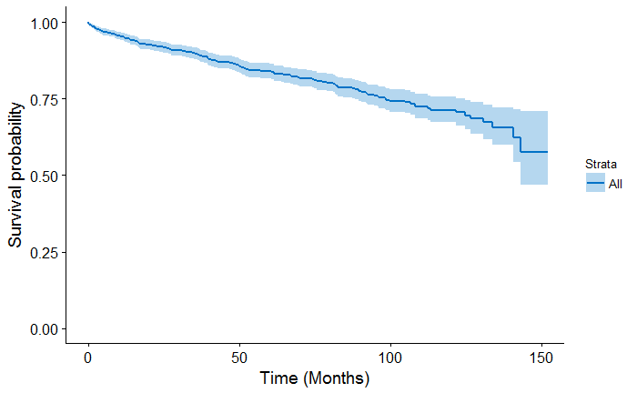

## Facility Type

```
_________________________________________________

## FACILITY_TYPE_F
_________________________________________________
Call: survfit(formula = Surv(DX_LASTCONTACT_DEATH_MONTHS, PUF_VITAL_STATUS ==
    0) ~ FACILITY_TYPE_F, data = data)

   276 observations deleted due to missingness
                                                n events median 0.95LCL 0.95UCL
FACILITY_TYPE_F=Community Cancer Program       11      3     NA    50.6      NA
FACILITY_TYPE_F=Comprehensive Comm Ca Program 150     50     NA    89.3      NA
FACILITY_TYPE_F=Academic/Research Program     567    105     NA   142.9      NA
FACILITY_TYPE_F=Integrated Network Ca Program  76     12     NA      NA      NA

Call: survfit(formula = Surv(DX_LASTCONTACT_DEATH_MONTHS, PUF_VITAL_STATUS ==
    0) ~ FACILITY_TYPE_F, data = data)

276 observations deleted due to missingness
                FACILITY_TYPE_F=Community Cancer Program
 time n.risk n.event survival std.err lower 95% CI upper 95% CI
   12      9       2    0.818   0.116        0.619            1
   24      8       0    0.818   0.116        0.619            1
   36      8       0    0.818   0.116        0.619            1
   48      7       0    0.818   0.116        0.619            1
   60      4       1    0.701   0.147        0.465            1
  120      1       0    0.701   0.147        0.465            1

                FACILITY_TYPE_F=Comprehensive Comm Ca Program
 time n.risk n.event survival std.err lower 95% CI upper 95% CI
   12    122      15    0.894  0.0258        0.845        0.946
   24    102      11    0.811  0.0335        0.748        0.879
   36     91       3    0.786  0.0354        0.719        0.859
   48     75       5    0.741  0.0386        0.670        0.821
   60     63       6    0.681  0.0427        0.602        0.770
  120     13      10    0.514  0.0600        0.409        0.646

                FACILITY_TYPE_F=Academic/Research Program
 time n.risk n.event survival std.err lower 95% CI upper 95% CI
   12    516      29    0.948 0.00946        0.929        0.966
   24    467      10    0.929 0.01098        0.908        0.951
```

[output cut: 27 more lines]

```
                                                coef exp(coef) se(coef)      z Pr(>|z|)
FACILITY_TYPE_FComprehensive Comm Ca Program  0.2198    1.2459   0.5946  0.370    0.712
FACILITY_TYPE_FAcademic/Research Program     -0.4393    0.6445   0.5858 -0.750    0.453
FACILITY_TYPE_FIntegrated Network Ca Program -0.6633    0.5152   0.6457 -1.027    0.304

                                             exp(coef) exp(-coef) lower .95 upper .95
FACILITY_TYPE_FComprehensive Comm Ca Program    1.2459     0.8027    0.3884     3.996
FACILITY_TYPE_FAcademic/Research Program        0.6445     1.5516    0.2045     2.032
FACILITY_TYPE_FIntegrated Network Ca Program    0.5152     1.9411    0.1453     1.826

Concordance= 0.58  (se = 0.019 )
Rsquare= 0.019   (max possible= 0.924 )
Likelihood ratio test= 15.61  on 3 df,   p=0.001363
Wald test            = 17.02  on 3 df,   p=0.0006996
Score (logrank) test = 17.71  on 3 df,   p=0.0005054
```

```
Removed 1 rows containing missing values (geom_errorbar).
```

```
## Unadjusted Kaplan Meier Overall Survival Curve for:  FACILITY_TYPE_F
```

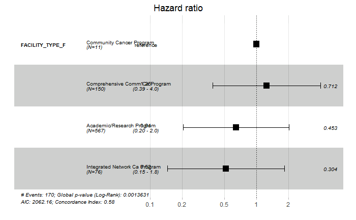

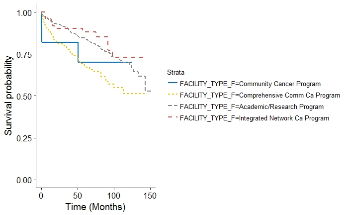

## Facility Location

```
_________________________________________________

## FACILITY_LOCATION_F
_________________________________________________
Call: survfit(formula = Surv(DX_LASTCONTACT_DEATH_MONTHS, PUF_VITAL_STATUS ==
    0) ~ FACILITY_LOCATION_F, data = data)

   276 observations deleted due to missingness
                                         n events median 0.95LCL 0.95UCL
FACILITY_LOCATION_F=New England         38      7     NA      NA      NA
FACILITY_LOCATION_F=Middle Atlantic    149     33     NA   121.6      NA
FACILITY_LOCATION_F=South Atlantic     148     23     NA      NA      NA
FACILITY_LOCATION_F=East North Central 129     22     NA      NA      NA
FACILITY_LOCATION_F=East South Central  42     11     NA    94.4      NA
FACILITY_LOCATION_F=West North Central  76     18    143    92.5      NA
FACILITY_LOCATION_F=West South Central  67     15    125   124.7      NA
FACILITY_LOCATION_F=Mountain            43     11     NA    92.0      NA
FACILITY_LOCATION_F=Pacific            112     30    133   106.6      NA

Call: survfit(formula = Surv(DX_LASTCONTACT_DEATH_MONTHS, PUF_VITAL_STATUS ==
    0) ~ FACILITY_LOCATION_F, data = data)

276 observations deleted due to missingness
                FACILITY_LOCATION_F=New England
 time n.risk n.event survival std.err lower 95% CI upper 95% CI
   12     36       0    1.000  0.0000        1.000        1.000
   24     33       1    0.972  0.0274        0.920        1.000
   36     27       0    0.972  0.0274        0.920        1.000
   48     22       1    0.936  0.0441        0.854        1.000
   60     19       2    0.851  0.0700        0.724        1.000
  120      4       3    0.681  0.1060        0.502        0.924

                FACILITY_LOCATION_F=Middle Atlantic
 time n.risk n.event survival std.err lower 95% CI upper 95% CI
   12    128      16    0.891  0.0258        0.841        0.943
   24    118       0    0.891  0.0258        0.841        0.943
   36     95       5    0.852  0.0299        0.795        0.913
   48     76       3    0.822  0.0336        0.758        0.890
   60     62       1    0.810  0.0350        0.745        0.882
  120      8       7    0.677  0.0573        0.574        0.800
```

[output cut: 87 more lines]

```
                                      exp(coef) exp(-coef) lower .95 upper .95
FACILITY_LOCATION_FMiddle Atlantic       1.4214     0.7035    0.6284     3.215
FACILITY_LOCATION_FSouth Atlantic        0.8807     1.1355    0.3776     2.054
FACILITY_LOCATION_FEast North Central    1.0529     0.9497    0.4496     2.466
FACILITY_LOCATION_FEast South Central    1.4674     0.6815    0.5684     3.788
FACILITY_LOCATION_FWest North Central    1.4136     0.7074    0.5902     3.386
FACILITY_LOCATION_FWest South Central    1.3334     0.7499    0.5436     3.271
FACILITY_LOCATION_FMountain              1.4051     0.7117    0.5446     3.625
FACILITY_LOCATION_FPacific               1.6150     0.6192    0.7093     3.678

Concordance= 0.546  (se = 0.024 )
Rsquare= 0.009   (max possible= 0.924 )
Likelihood ratio test= 7.28  on 8 df,   p=0.5065
Wald test            = 6.95  on 8 df,   p=0.5424
Score (logrank) test = 7.07  on 8 df,   p=0.5292
```

```
Removed 1 rows containing missing values (geom_errorbar).
```

```
## Unadjusted Kaplan Meier Overall Survival Curve for:  FACILITY_LOCATION_F
```

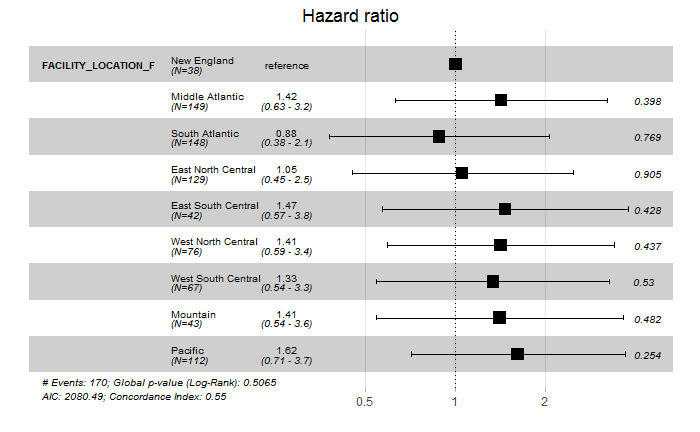

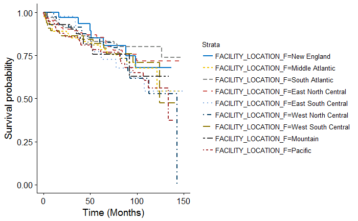

## Facility Geography

```
_________________________________________________

## FACILITY_GEOGRAPHY
_________________________________________________
Call: survfit(formula = Surv(DX_LASTCONTACT_DEATH_MONTHS, PUF_VITAL_STATUS ==
    0) ~ FACILITY_GEOGRAPHY, data = data)

   276 observations deleted due to missingness
                               n events median 0.95LCL 0.95UCL
FACILITY_GEOGRAPHY=Northeast 187     40     NA     122      NA
FACILITY_GEOGRAPHY=South     215     38     NA      NA      NA
FACILITY_GEOGRAPHY=Midwest   247     51    143     143      NA
FACILITY_GEOGRAPHY=West      155     41    133     112      NA

Call: survfit(formula = Surv(DX_LASTCONTACT_DEATH_MONTHS, PUF_VITAL_STATUS ==
    0) ~ FACILITY_GEOGRAPHY, data = data)

276 observations deleted due to missingness
                FACILITY_GEOGRAPHY=Northeast
 time n.risk n.event survival std.err lower 95% CI upper 95% CI
   12    164      16    0.913  0.0209        0.873        0.954
   24    151       1    0.907  0.0215        0.866        0.950
   36    122       5    0.876  0.0248        0.829        0.926
   48     98       4    0.845  0.0285        0.791        0.902
   60     81       3    0.818  0.0314        0.759        0.882
  120     12      10    0.672  0.0513        0.579        0.780

                FACILITY_GEOGRAPHY=South
 time n.risk n.event survival std.err lower 95% CI upper 95% CI
   12    188      13    0.936  0.0171        0.904        0.971
   24    164       8    0.895  0.0217        0.854        0.939
   36    141       2    0.883  0.0230        0.839        0.929
   48    122       4    0.857  0.0257        0.808        0.909
   60    101       4    0.828  0.0286        0.774        0.886
  120     22       5    0.773  0.0361        0.706        0.847

                FACILITY_GEOGRAPHY=Midwest
 time n.risk n.event survival std.err lower 95% CI upper 95% CI
   12    229       9    0.963  0.0121        0.939        0.987
   24    202       9    0.924  0.0172        0.891        0.958
```

[output cut: 27 more lines]

```
                              coef exp(coef) se(coef)      z Pr(>|z|)
FACILITY_GEOGRAPHYSouth   -0.26298   0.76876  0.22693 -1.159    0.247
FACILITY_GEOGRAPHYMidwest -0.06501   0.93706  0.21131 -0.308    0.758
FACILITY_GEOGRAPHYWest     0.15978   1.17325  0.22251  0.718    0.473

                          exp(coef) exp(-coef) lower .95 upper .95
FACILITY_GEOGRAPHYSouth      0.7688     1.3008    0.4928     1.199
FACILITY_GEOGRAPHYMidwest    0.9371     1.0672    0.6193     1.418
FACILITY_GEOGRAPHYWest       1.1732     0.8523    0.7586     1.815

Concordance= 0.532  (se = 0.023 )
Rsquare= 0.005   (max possible= 0.924 )
Likelihood ratio test= 3.64  on 3 df,   p=0.3034
Wald test            = 3.61  on 3 df,   p=0.3066
Score (logrank) test = 3.64  on 3 df,   p=0.3026
```

```
Removed 1 rows containing missing values (geom_errorbar).
```

```
## Unadjusted Kaplan Meier Overall Survival Curve for:  FACILITY_GEOGRAPHY
```

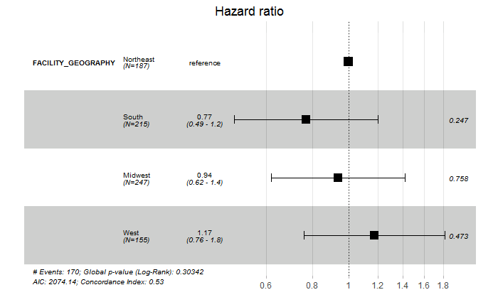

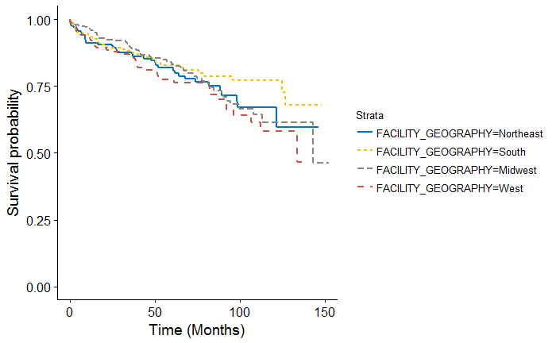

## Age Group

```
_________________________________________________

## AGE_F
_________________________________________________
Call: survfit(formula = Surv(DX_LASTCONTACT_DEATH_MONTHS, PUF_VITAL_STATUS ==
    0) ~ AGE_F, data = data)

   1 observation deleted due to missingness
                 n events median 0.95LCL 0.95UCL
AGE_F=(0,54]   567     60     NA      NA      NA
AGE_F=(54,64]  208     29     NA      NA      NA
AGE_F=(64,74]  190     46     NA      NA      NA
AGE_F=(74,100] 114     62   64.5    50.6    81.9

Call: survfit(formula = Surv(DX_LASTCONTACT_DEATH_MONTHS, PUF_VITAL_STATUS ==
    0) ~ AGE_F, data = data)

1 observation deleted due to missingness
                AGE_F=(0,54]
 time n.risk n.event survival std.err lower 95% CI upper 95% CI
   12    523       8    0.985 0.00511        0.975        0.996
   24    468      13    0.960 0.00851        0.944        0.977
   36    394      10    0.939 0.01063        0.918        0.960
   48    340       7    0.922 0.01232        0.898        0.946
   60    282       5    0.908 0.01364        0.881        0.935
  120     58      14    0.827 0.02525        0.779        0.878

                AGE_F=(54,64]
 time n.risk n.event survival std.err lower 95% CI upper 95% CI
   12    190       9    0.956  0.0145        0.928        0.984
   24    173       2    0.945  0.0161        0.914        0.977
   36    144       2    0.932  0.0182        0.897        0.969
   48    118       6    0.891  0.0239        0.846        0.939
   60     95       4    0.859  0.0281        0.805        0.916
  120     15       5    0.769  0.0493        0.678        0.872

                AGE_F=(64,74]
 time n.risk n.event survival std.err lower 95% CI upper 95% CI
   12    168      16    0.914  0.0206        0.874        0.955
   24    152       7    0.875  0.0245        0.828        0.924
```

[output cut: 29 more lines]

```
AGE_F(64,74]  0.8950    2.4473   0.1961  4.564 5.01e-06 ***
AGE_F(74,100] 1.9754    7.2095   0.1822 10.841  < 2e-16 ***
---
Signif. codes:  0 *** 0.001 ** 0.01 * 0.05 . 0.1   1

              exp(coef) exp(-coef) lower .95 upper .95
AGE_F(54,64]      1.357     0.7368    0.8711     2.114
AGE_F(64,74]      2.447     0.4086    1.6664     3.594
AGE_F(74,100]     7.210     0.1387    5.0443    10.304

Concordance= 0.678  (se = 0.02 )
Rsquare= 0.097   (max possible= 0.903 )
Likelihood ratio test= 110  on 3 df,   p=0
Wald test            = 128.6  on 3 df,   p=0
Score (logrank) test = 163.7  on 3 df,   p=0
```

```
Removed 1 rows containing missing values (geom_errorbar).
```

```
## Unadjusted Kaplan Meier Overall Survival Curve for:  AGE_F
```

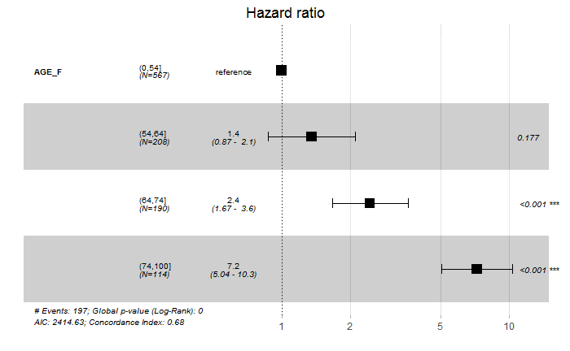

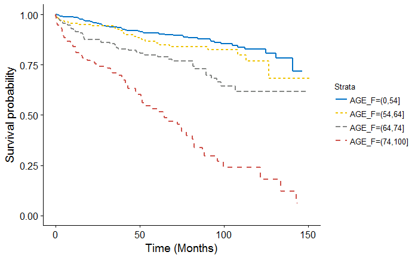

## Age Group

```
_________________________________________________

## AGE_40
_________________________________________________
Call: survfit(formula = Surv(DX_LASTCONTACT_DEATH_MONTHS, PUF_VITAL_STATUS ==
    0) ~ AGE_40, data = data)

   1 observation deleted due to missingness
                  n events median 0.95LCL 0.95UCL
AGE_40=(0,40]   288     27     NA      NA      NA
AGE_40=(40,100] 791    170     NA     143      NA

Call: survfit(formula = Surv(DX_LASTCONTACT_DEATH_MONTHS, PUF_VITAL_STATUS ==
    0) ~ AGE_40, data = data)

1 observation deleted due to missingness
                AGE_40=(0,40]
 time n.risk n.event survival std.err lower 95% CI upper 95% CI
   12    267       3    0.989 0.00616        0.977        1.000
   24    245       5    0.970 0.01041        0.950        0.991
   36    204       6    0.946 0.01415        0.918        0.974
   48    179       4    0.926 0.01684        0.894        0.960
   60    144       3    0.911 0.01887        0.874        0.948
  120     32       4    0.861 0.03116        0.802        0.925

                AGE_40=(40,100]
 time n.risk n.event survival std.err lower 95% CI upper 95% CI
   12    703      49    0.936 0.00881        0.919        0.954
   24    623      25    0.902 0.01083        0.881        0.924
   36    519      14    0.880 0.01206        0.857        0.904
   48    430      21    0.842 0.01409        0.815        0.870
   60    356      14    0.813 0.01558        0.783        0.844
  120     61      42    0.661 0.02631        0.611        0.714





## Univariable Cox Proportional Hazard Model for:  AGE_40

Call:
coxph(formula = Surv(DX_LASTCONTACT_DEATH_MONTHS, PUF_VITAL_STATUS ==
    0) ~ AGE_40, data = data)

  n= 1079, number of events= 197
   (1 observation deleted due to missingness)

                 coef exp(coef) se(coef)     z Pr(>|z|)
AGE_40(40,100] 0.9238    2.5187   0.2072 4.457 8.29e-06 ***
---
Signif. codes:  0 *** 0.001 ** 0.01 * 0.05 . 0.1   1

               exp(coef) exp(-coef) lower .95 upper .95
AGE_40(40,100]     2.519      0.397     1.678     3.781

Concordance= 0.574  (se = 0.017 )
Rsquare= 0.023   (max possible= 0.903 )
Likelihood ratio test= 24.6  on 1 df,   p=7.073e-07
Wald test            = 19.87  on 1 df,   p=8.294e-06
Score (logrank) test = 21.32  on 1 df,   p=3.887e-06
```

```
Removed 1 rows containing missing values (geom_errorbar).
```

```
## Unadjusted Kaplan Meier Overall Survival Curve for:  AGE_40
```

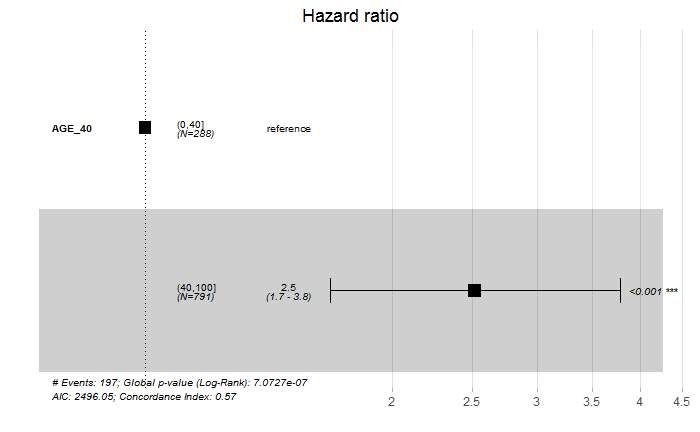

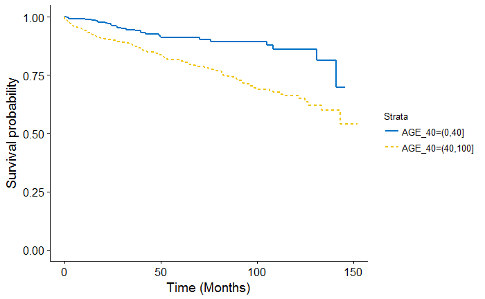

## Gender

```
_________________________________________________

## SEX_F
_________________________________________________
Call: survfit(formula = Surv(DX_LASTCONTACT_DEATH_MONTHS, PUF_VITAL_STATUS ==
    0) ~ SEX_F, data = data)

               n events median 0.95LCL 0.95UCL
SEX_F=Male   567    129     NA     133      NA
SEX_F=Female 513     68     NA     143      NA

Call: survfit(formula = Surv(DX_LASTCONTACT_DEATH_MONTHS, PUF_VITAL_STATUS ==
    0) ~ SEX_F, data = data)

                SEX_F=Male
 time n.risk n.event survival std.err lower 95% CI upper 95% CI
   12    507      33    0.940  0.0101        0.921        0.960
   24    459      19    0.904  0.0126        0.880        0.929
   36    396      11    0.881  0.0141        0.854        0.909
   48    332      17    0.842  0.0164        0.810        0.874
   60    274       8    0.820  0.0176        0.786        0.856
  120     47      36    0.649  0.0309        0.592        0.713

                SEX_F=Female
 time n.risk n.event survival std.err lower 95% CI upper 95% CI
   12    464      19    0.962 0.00858        0.945        0.979
   24    410      11    0.938 0.01095        0.917        0.960
   36    328       9    0.916 0.01300        0.891        0.942
   48    277       8    0.892 0.01513        0.863        0.922
   60    226       9    0.861 0.01777        0.827        0.897
  120     46      10    0.793 0.02773        0.741        0.850





## Univariable Cox Proportional Hazard Model for:  SEX_F

Call:
coxph(formula = Surv(DX_LASTCONTACT_DEATH_MONTHS, PUF_VITAL_STATUS ==
    0) ~ SEX_F, data = data)

  n= 1080, number of events= 197

               coef exp(coef) se(coef)      z Pr(>|z|)
SEX_FFemale -0.5136    0.5984   0.1499 -3.426 0.000613 ***
---
Signif. codes:  0 *** 0.001 ** 0.01 * 0.05 . 0.1   1

            exp(coef) exp(-coef) lower .95 upper .95
SEX_FFemale    0.5984      1.671     0.446    0.8027

Concordance= 0.554  (se = 0.019 )
Rsquare= 0.011   (max possible= 0.903 )
Likelihood ratio test= 12.25  on 1 df,   p=0.0004645
Wald test            = 11.74  on 1 df,   p=0.000613
Score (logrank) test = 12  on 1 df,   p=0.0005332
```

```
Removed 1 rows containing missing values (geom_errorbar).
```

```
## Unadjusted Kaplan Meier Overall Survival Curve for:  SEX_F
```

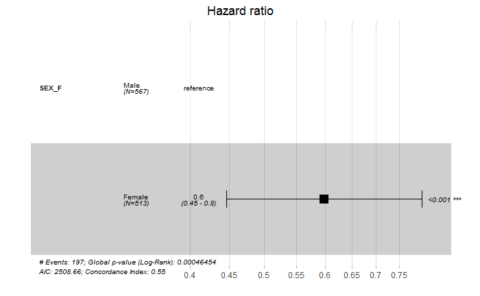

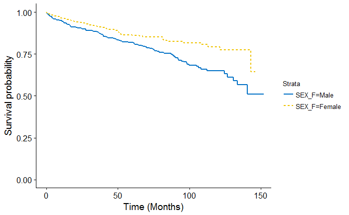

## RACE_F

```
_________________________________________________

## RACE_F
_________________________________________________
Call: survfit(formula = Surv(DX_LASTCONTACT_DEATH_MONTHS, PUF_VITAL_STATUS ==
    0) ~ RACE_F, data = data)

                   n events median 0.95LCL 0.95UCL
RACE_F=White     942    178     NA     143      NA
RACE_F=Black      61      9     NA     108      NA
RACE_F=Other/Unk  52      7     NA      NA      NA
RACE_F=Asian      25      3     NA      NA      NA

Call: survfit(formula = Surv(DX_LASTCONTACT_DEATH_MONTHS, PUF_VITAL_STATUS ==
    0) ~ RACE_F, data = data)

                RACE_F=White
 time n.risk n.event survival std.err lower 95% CI upper 95% CI
   12    855      45    0.951  0.0071        0.937        0.965
   24    770      25    0.923  0.0089        0.905        0.940
   36    635      20    0.897  0.0103        0.877        0.917
   48    531      22    0.864  0.0121        0.841        0.888
   60    432      16    0.837  0.0135        0.810        0.864
  120     84      43    0.704  0.0230        0.660        0.750

                RACE_F=Black
 time n.risk n.event survival std.err lower 95% CI upper 95% CI
   12     51       3    0.947  0.0299        0.890        1.000
   24     42       3    0.890  0.0423        0.811        0.977
   36     38       0    0.890  0.0423        0.811        0.977
   48     32       1    0.863  0.0489        0.773        0.965
   60     27       1    0.836  0.0547        0.735        0.950
  120      3       1    0.668  0.1557        0.423        1.000

                RACE_F=Other/Unk
 time n.risk n.event survival std.err lower 95% CI upper 95% CI
   12     44       3    0.939  0.0339        0.875        1.000
   24     42       0    0.939  0.0339        0.875        1.000
   36     38       0    0.939  0.0339        0.875        1.000
   48     35       2    0.889  0.0474        0.800        0.987
```

[output cut: 24 more lines]

```
                   coef exp(coef) se(coef)      z Pr(>|z|)
RACE_FBlack     -0.1369    0.8721   0.3418 -0.400    0.689
RACE_FOther/Unk -0.4316    0.6495   0.3856 -1.119    0.263
RACE_FAsian     -0.2963    0.7436   0.5824 -0.509    0.611

                exp(coef) exp(-coef) lower .95 upper .95
RACE_FBlack        0.8721      1.147    0.4463     1.704
RACE_FOther/Unk    0.6495      1.540    0.3050     1.383
RACE_FAsian        0.7436      1.345    0.2375     2.328

Concordance= 0.507  (se = 0.013 )
Rsquare= 0.002   (max possible= 0.903 )
Likelihood ratio test= 1.79  on 3 df,   p=0.6168
Wald test            = 1.6  on 3 df,   p=0.6595
Score (logrank) test = 1.62  on 3 df,   p=0.6548
```

```
Removed 1 rows containing missing values (geom_errorbar).
```

```
## Unadjusted Kaplan Meier Overall Survival Curve for:  RACE_F
```

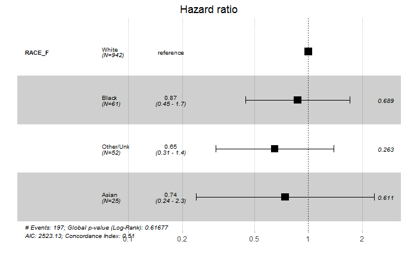

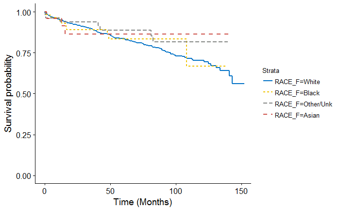

## Hispanic

```
_________________________________________________

## HISPANIC
_________________________________________________
Call: survfit(formula = Surv(DX_LASTCONTACT_DEATH_MONTHS, PUF_VITAL_STATUS ==
    0) ~ HISPANIC, data = data)

                   n events median 0.95LCL 0.95UCL
HISPANIC=No      924    175     NA     143      NA
HISPANIC=Yes      85      8     NA     141      NA
HISPANIC=Unknown  71     14     NA      NA      NA

Call: survfit(formula = Surv(DX_LASTCONTACT_DEATH_MONTHS, PUF_VITAL_STATUS ==
    0) ~ HISPANIC, data = data)

                HISPANIC=No
 time n.risk n.event survival std.err lower 95% CI upper 95% CI
   12    829      45    0.950 0.00728        0.936        0.964
   24    734      29    0.916 0.00940        0.897        0.934
   36    607      18    0.892 0.01073        0.871        0.913
   48    508      21    0.859 0.01249        0.835        0.884
   60    415      14    0.834 0.01377        0.808        0.862
  120     73      42    0.694 0.02436        0.648        0.744

                HISPANIC=Yes
 time n.risk n.event survival std.err lower 95% CI upper 95% CI
   12     79       3    0.964  0.0204        0.925        1.000
   24     74       1    0.952  0.0235        0.907        0.999
   36     63       0    0.952  0.0235        0.907        0.999
   48     49       2    0.920  0.0319        0.859        0.984
   60     37       1    0.895  0.0392        0.822        0.976
  120      8       0    0.895  0.0392        0.822        0.976

                HISPANIC=Unknown
 time n.risk n.event survival std.err lower 95% CI upper 95% CI
   12     63       4    0.942  0.0282        0.888        0.999
   24     61       0    0.942  0.0282        0.888        0.999
   36     54       2    0.910  0.0352        0.844        0.982
   48     52       2    0.876  0.0412        0.799        0.961
   60     48       2    0.842  0.0461        0.757        0.938
```

[output cut: 14 more lines]

```
                   coef exp(coef) se(coef)      z Pr(>|z|)
HISPANICYes     -0.7944    0.4519   0.3616 -2.196   0.0281 *
HISPANICUnknown -0.2036    0.8158   0.2784 -0.731   0.4646
---
Signif. codes:  0 *** 0.001 ** 0.01 * 0.05 . 0.1   1

                exp(coef) exp(-coef) lower .95 upper .95
HISPANICYes        0.4519      2.213    0.2224     0.918
HISPANICUnknown    0.8158      1.226    0.4728     1.408

Concordance= 0.525  (se = 0.014 )
Rsquare= 0.006   (max possible= 0.903 )
Likelihood ratio test= 6.51  on 2 df,   p=0.03867
Wald test            = 5.19  on 2 df,   p=0.07458
Score (logrank) test = 5.44  on 2 df,   p=0.06588
```

```
Removed 1 rows containing missing values (geom_errorbar).
```

```
## Unadjusted Kaplan Meier Overall Survival Curve for:  HISPANIC
```

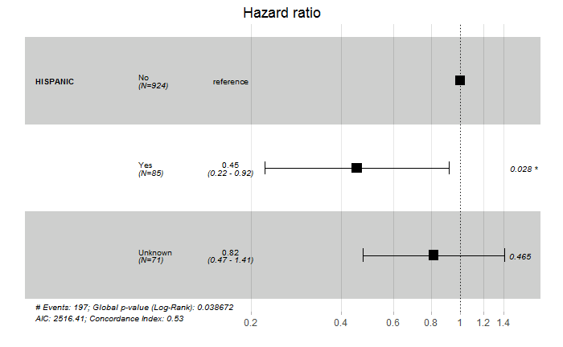

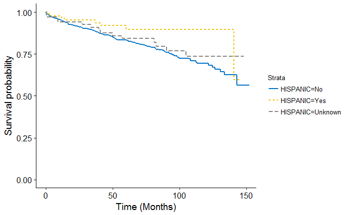

## Insurance Status

```
_________________________________________________

## INSURANCE_F
_________________________________________________
Call: survfit(formula = Surv(DX_LASTCONTACT_DEATH_MONTHS, PUF_VITAL_STATUS ==
    0) ~ INSURANCE_F, data = data)

                               n events median 0.95LCL 0.95UCL
INSURANCE_F=Private          620     67     NA      NA      NA
INSURANCE_F=None              50      7    125   108.1      NA
INSURANCE_F=Medicaid          91     25    131    98.4      NA
INSURANCE_F=Medicare         285     92    107    89.3      NA
INSURANCE_F=Other Government  21      4     NA   112.3      NA
INSURANCE_F=Unknown           13      2     NA   142.9      NA

Call: survfit(formula = Surv(DX_LASTCONTACT_DEATH_MONTHS, PUF_VITAL_STATUS ==
    0) ~ INSURANCE_F, data = data)

                INSURANCE_F=Private
 time n.risk n.event survival std.err lower 95% CI upper 95% CI
   12    573      17    0.972 0.00669        0.959        0.985
   24    520      11    0.953 0.00872        0.936        0.970
   36    440       8    0.937 0.01020        0.917        0.957
   48    379       7    0.921 0.01163        0.899        0.944
   60    313       6    0.906 0.01307        0.880        0.932
  120     66      15    0.839 0.02154        0.798        0.883

                INSURANCE_F=None
 time n.risk n.event survival std.err lower 95% CI upper 95% CI
   12     44       0    1.000  0.0000        1.000        1.000
   24     36       0    1.000  0.0000        1.000        1.000
   36     33       1    0.971  0.0290        0.915        1.000
   48     26       1    0.938  0.0424        0.859        1.000
   60     20       1    0.896  0.0581        0.789        1.000
  120      4       3    0.630  0.1409        0.406        0.976

                INSURANCE_F=Medicaid
 time n.risk n.event survival std.err lower 95% CI upper 95% CI
   12     79       8    0.909  0.0306        0.851        0.971
   24     71       4    0.862  0.0369        0.793        0.938
```

[output cut: 49 more lines]

```
---
Signif. codes:  0 *** 0.001 ** 0.01 * 0.05 . 0.1   1

                            exp(coef) exp(-coef) lower .95 upper .95
INSURANCE_FNone                1.4647     0.6827    0.6723     3.191
INSURANCE_FMedicaid            3.3257     0.3007    2.0968     5.275
INSURANCE_FMedicare            3.5879     0.2787    2.6170     4.919
INSURANCE_FOther Government    1.8328     0.5456    0.6679     5.029
INSURANCE_FUnknown             0.8437     1.1853    0.2050     3.473

Concordance= 0.653  (se = 0.02 )
Rsquare= 0.065   (max possible= 0.903 )
Likelihood ratio test= 72.59  on 5 df,   p=2.953e-14
Wald test            = 70.38  on 5 df,   p=8.538e-14
Score (logrank) test = 79.65  on 5 df,   p=9.992e-16
```

```
Removed 1 rows containing missing values (geom_errorbar).
```

```
## Unadjusted Kaplan Meier Overall Survival Curve for:  INSURANCE_F
```

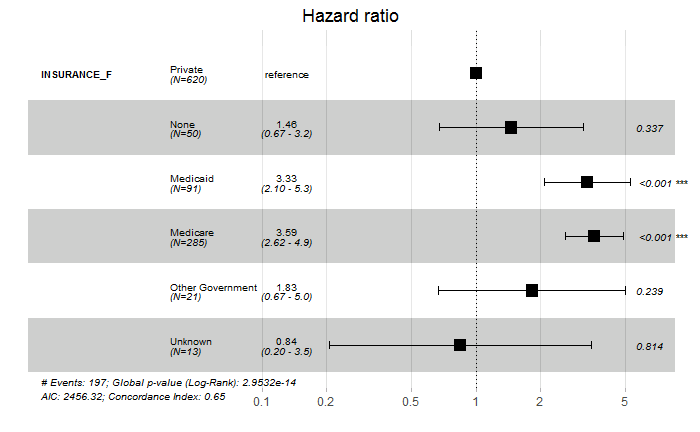

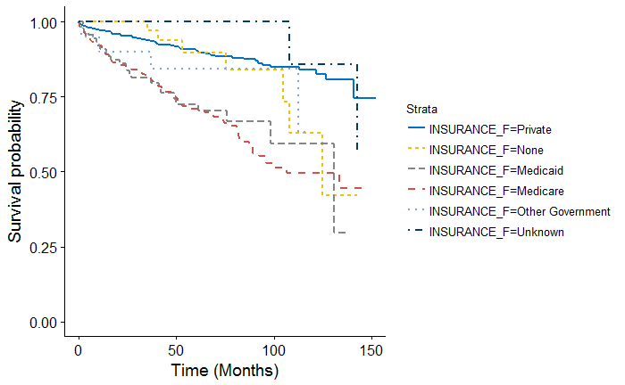

## Income

```
_________________________________________________

## INCOME_F
_________________________________________________
Call: survfit(formula = Surv(DX_LASTCONTACT_DEATH_MONTHS, PUF_VITAL_STATUS ==
    0) ~ INCOME_F, data = data)

   18 observations deleted due to missingness
                             n events median 0.95LCL 0.95UCL
INCOME_F=Less than $38,000 151     32     NA     131      NA
INCOME_F=$38,000 - $47,999 234     40    143     143      NA
INCOME_F=$48,000 - $62,999 312     67     NA     133      NA
INCOME_F=$63,000 +         365     51     NA     141      NA

Call: survfit(formula = Surv(DX_LASTCONTACT_DEATH_MONTHS, PUF_VITAL_STATUS ==
    0) ~ INCOME_F, data = data)

18 observations deleted due to missingness
                INCOME_F=Less than $38,000
 time n.risk n.event survival std.err lower 95% CI upper 95% CI
   12    130       9    0.938  0.0202        0.899        0.978
   24    113       5    0.901  0.0251        0.853        0.952
   36     95       2    0.883  0.0277        0.830        0.939
   48     84       3    0.853  0.0316        0.794        0.918
   60     67       4    0.811  0.0366        0.742        0.886
  120     10       8    0.637  0.0646        0.523        0.777

                INCOME_F=$38,000 - $47,999
 time n.risk n.event survival std.err lower 95% CI upper 95% CI
   12    207      11    0.951  0.0143        0.924        0.980
   24    187       5    0.928  0.0175        0.894        0.962
   36    157       6    0.895  0.0213        0.855        0.938
   48    132       4    0.871  0.0238        0.826        0.919
   60    113       3    0.850  0.0262        0.801        0.903
  120     19       9    0.754  0.0392        0.681        0.835

                INCOME_F=$48,000 - $62,999
 time n.risk n.event survival std.err lower 95% CI upper 95% CI
   12    282      17    0.945  0.0131        0.919        0.971
   24    252       9    0.914  0.0162        0.883        0.946
```

[output cut: 29 more lines]

```
INCOME_F$48,000 - $62,999 -0.04141   0.95944  0.21497 -0.193   0.8473
INCOME_F$63,000 +         -0.50471   0.60368  0.22558 -2.237   0.0253 *
---
Signif. codes:  0 *** 0.001 ** 0.01 * 0.05 . 0.1   1

                          exp(coef) exp(-coef) lower .95 upper .95
INCOME_F$38,000 - $47,999    0.7881      1.269    0.4951    1.2547
INCOME_F$48,000 - $62,999    0.9594      1.042    0.6295    1.4622
INCOME_F$63,000 +            0.6037      1.657    0.3880    0.9393

Concordance= 0.546  (se = 0.022 )
Rsquare= 0.008   (max possible= 0.898 )
Likelihood ratio test= 8.02  on 3 df,   p=0.04554
Wald test            = 7.76  on 3 df,   p=0.05132
Score (logrank) test = 7.88  on 3 df,   p=0.04854
```

```
Removed 1 rows containing missing values (geom_errorbar).
```

```
## Unadjusted Kaplan Meier Overall Survival Curve for:  INCOME_F
```

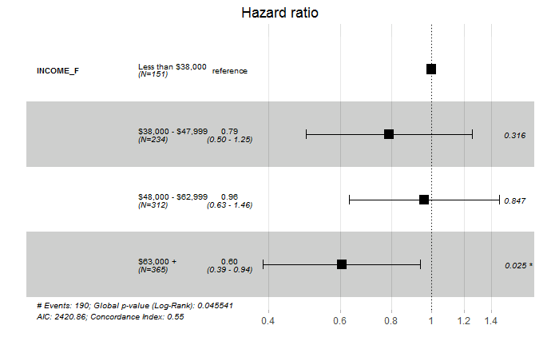

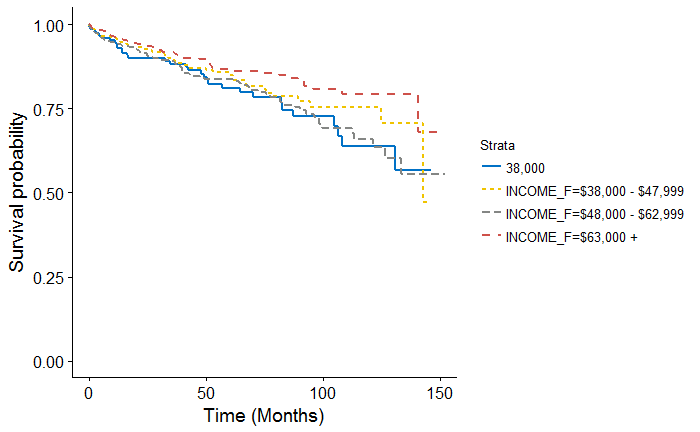

## Education

```
_________________________________________________

## EDUCATION_F
_________________________________________________
Call: survfit(formula = Surv(DX_LASTCONTACT_DEATH_MONTHS, PUF_VITAL_STATUS ==
    0) ~ EDUCATION_F, data = data)

   16 observations deleted due to missingness
                           n events median 0.95LCL 0.95UCL
EDUCATION_F=21% or more  162     26    141     131      NA
EDUCATION_F=13 - 20.9%   254     45     NA      NA      NA
EDUCATION_F=7 - 12.9%    376     79     NA     143      NA
EDUCATION_F=Less than 7% 272     41     NA      NA      NA

Call: survfit(formula = Surv(DX_LASTCONTACT_DEATH_MONTHS, PUF_VITAL_STATUS ==
    0) ~ EDUCATION_F, data = data)

16 observations deleted due to missingness
                EDUCATION_F=21% or more
 time n.risk n.event survival std.err lower 95% CI upper 95% CI
   12    144       7    0.955  0.0166        0.923        0.988
   24    129       3    0.935  0.0199        0.897        0.975
   36    105       1    0.927  0.0214        0.885        0.970
   48     86       3    0.897  0.0267        0.846        0.951
   60     71       1    0.885  0.0288        0.831        0.944
  120     12       8    0.698  0.0698        0.574        0.849

                EDUCATION_F=13 - 20.9%
 time n.risk n.event survival std.err lower 95% CI upper 95% CI
   12    225      11    0.956  0.0131        0.930        0.982
   24    206       5    0.934  0.0160        0.903        0.966
   36    171       8    0.895  0.0203        0.856        0.936
   48    143       6    0.862  0.0236        0.817        0.910
   60    118       5    0.831  0.0265        0.781        0.885
  120     17      10    0.723  0.0405        0.648        0.807

                EDUCATION_F=7 - 12.9%
 time n.risk n.event survival std.err lower 95% CI upper 95% CI
   12    338      23    0.937  0.0127        0.913        0.962
   24    302      14    0.897  0.0160        0.867        0.929
```

[output cut: 27 more lines]

```
                           coef exp(coef) se(coef)      z Pr(>|z|)
EDUCATION_F13 - 20.9%    0.1304    1.1392   0.2466  0.529    0.597
EDUCATION_F7 - 12.9%     0.2416    1.2733   0.2262  1.068    0.285
EDUCATION_FLess than 7% -0.1186    0.8882   0.2508 -0.473    0.636

                        exp(coef) exp(-coef) lower .95 upper .95
EDUCATION_F13 - 20.9%      1.1392     0.8778    0.7027     1.847
EDUCATION_F7 - 12.9%       1.2733     0.7854    0.8173     1.984
EDUCATION_FLess than 7%    0.8882     1.1259    0.5432     1.452

Concordance= 0.548  (se = 0.022 )
Rsquare= 0.004   (max possible= 0.899 )
Likelihood ratio test= 3.93  on 3 df,   p=0.2695
Wald test            = 3.84  on 3 df,   p=0.2793
Score (logrank) test = 3.87  on 3 df,   p=0.2758
```

```
Removed 1 rows containing missing values (geom_errorbar).
```

```
## Unadjusted Kaplan Meier Overall Survival Curve for:  EDUCATION_F
```

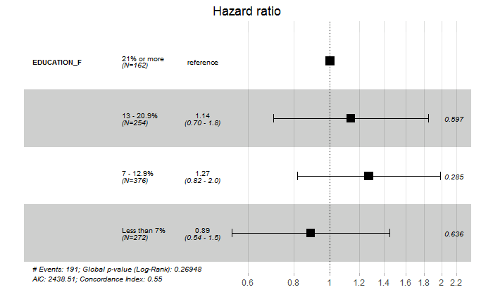

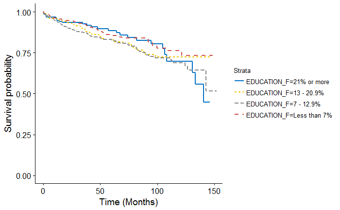

## Urban/Rural

```
_________________________________________________

## U_R_F
_________________________________________________
Call: survfit(formula = Surv(DX_LASTCONTACT_DEATH_MONTHS, PUF_VITAL_STATUS ==
    0) ~ U_R_F, data = data)

   41 observations deleted due to missingness
              n events median 0.95LCL 0.95UCL
U_R_F=Metro 855    142     NA   142.9      NA
U_R_F=Urban 166     41    112    98.4      NA
U_R_F=Rural  18      2     NA      NA      NA

Call: survfit(formula = Surv(DX_LASTCONTACT_DEATH_MONTHS, PUF_VITAL_STATUS ==
    0) ~ U_R_F, data = data)

41 observations deleted due to missingness
                U_R_F=Metro
 time n.risk n.event survival std.err lower 95% CI upper 95% CI
   12    783      41    0.951 0.00745        0.937        0.966
   24    713      17    0.930 0.00889        0.913        0.947
   36    598      14    0.910 0.01011        0.891        0.930
   48    507      21    0.877 0.01212        0.853        0.901
   60    410      13    0.853 0.01349        0.827        0.880
  120     84      29    0.761 0.02086        0.721        0.803

                U_R_F=Urban
 time n.risk n.event survival std.err lower 95% CI upper 95% CI
   12    139       9    0.944  0.0182        0.909        0.980
   24    121       6    0.901  0.0243        0.855        0.950
   36     97       6    0.854  0.0299        0.797        0.914
   48     78       3    0.825  0.0331        0.763        0.893
   60     68       2    0.803  0.0356        0.736        0.876
  120      6      15    0.442  0.0863        0.302        0.648

                U_R_F=Rural
 time n.risk n.event survival std.err lower 95% CI upper 95% CI
   12     15       1    0.941  0.0571        0.836            1
   24     11       1    0.878  0.0807        0.734            1
   36      8       0    0.878  0.0807        0.734            1
```

[output cut: 17 more lines]

```
              coef exp(coef) se(coef)      z Pr(>|z|)
U_R_FUrban  0.5960    1.8149   0.1780  3.349 0.000812 ***
U_R_FRural -0.2748    0.7597   0.7127 -0.386 0.699832
---
Signif. codes:  0 *** 0.001 ** 0.01 * 0.05 . 0.1   1

           exp(coef) exp(-coef) lower .95 upper .95
U_R_FUrban    1.8149      0.551    1.2804     2.572
U_R_FRural    0.7597      1.316    0.1879     3.071

Concordance= 0.533  (se = 0.015 )
Rsquare= 0.01   (max possible= 0.896 )
Likelihood ratio test= 10.33  on 2 df,   p=0.005721
Wald test            = 11.53  on 2 df,   p=0.003131
Score (logrank) test = 11.88  on 2 df,   p=0.002626
```

```
Removed 1 rows containing missing values (geom_errorbar).
```

```
## Unadjusted Kaplan Meier Overall Survival Curve for:  U_R_F
```

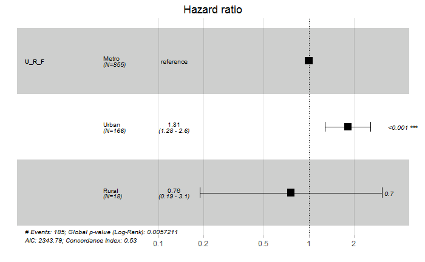

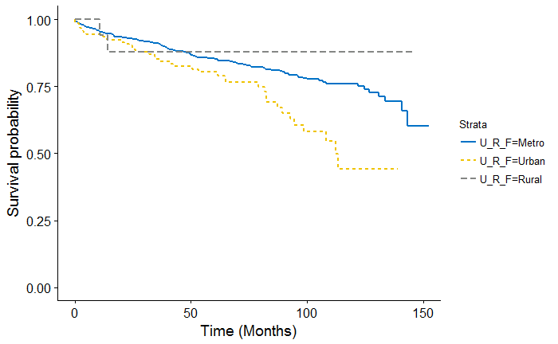

## Comorbidities

```
_________________________________________________

## CDCC_TOTAL
_________________________________________________
Call: survfit(formula = Surv(DX_LASTCONTACT_DEATH_MONTHS, PUF_VITAL_STATUS ==
    0) ~ CDCC_TOTAL, data = data)

               n events median 0.95LCL 0.95UCL
CDCC_TOTAL=0 893    149     NA   142.9      NA
CDCC_TOTAL=1 138     31     NA      NA      NA
CDCC_TOTAL=2  41     15   90.3    84.4      NA
CDCC_TOTAL=3   8      2     NA    12.1      NA

Call: survfit(formula = Surv(DX_LASTCONTACT_DEATH_MONTHS, PUF_VITAL_STATUS ==
    0) ~ CDCC_TOTAL, data = data)

                CDCC_TOTAL=0
 time n.risk n.event survival std.err lower 95% CI upper 95% CI
   12    814      37    0.957 0.00685        0.944        0.971
   24    730      23    0.930 0.00877        0.913        0.947
   36    611      12    0.913 0.00979        0.894        0.933
   48    510      24    0.876 0.01206        0.852        0.900
   60    424      12    0.854 0.01327        0.828        0.880
  120     83      34    0.740 0.02280        0.697        0.786

                CDCC_TOTAL=1
 time n.risk n.event survival std.err lower 95% CI upper 95% CI
   12    118       9    0.933  0.0217        0.891        0.976
   24    104       5    0.892  0.0274        0.840        0.947
   36     83       5    0.847  0.0326        0.785        0.913
   48     73       1    0.835  0.0341        0.771        0.905
   60     54       5    0.772  0.0416        0.695        0.858
  120      7       6    0.647  0.0597        0.540        0.776

                CDCC_TOTAL=2
 time n.risk n.event survival std.err lower 95% CI upper 95% CI
   12     33       5    0.873  0.0530        0.775        0.984
   24     31       1    0.847  0.0576        0.741        0.968
   36     27       3    0.762  0.0696        0.637        0.912
   48     24       0    0.762  0.0696        0.637        0.912
```

[output cut: 25 more lines]

```
CDCC_TOTAL2 0.8626    2.3693   0.2712 3.181  0.00147 **
CDCC_TOTAL3 0.9162    2.4999   0.7126 1.286  0.19850
---
Signif. codes:  0 *** 0.001 ** 0.01 * 0.05 . 0.1   1

            exp(coef) exp(-coef) lower .95 upper .95
CDCC_TOTAL1     1.593     0.6276    1.0811     2.348
CDCC_TOTAL2     2.369     0.4221    1.3926     4.031
CDCC_TOTAL3     2.500     0.4000    0.6186    10.103

Concordance= 0.552  (se = 0.014 )
Rsquare= 0.012   (max possible= 0.903 )
Likelihood ratio test= 13.04  on 3 df,   p=0.004542
Wald test            = 15.17  on 3 df,   p=0.001676
Score (logrank) test = 15.89  on 3 df,   p=0.001193
```

```
Removed 1 rows containing missing values (geom_errorbar).
```

```
## Unadjusted Kaplan Meier Overall Survival Curve for:  CDCC_TOTAL
```

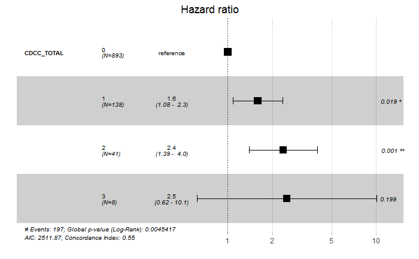

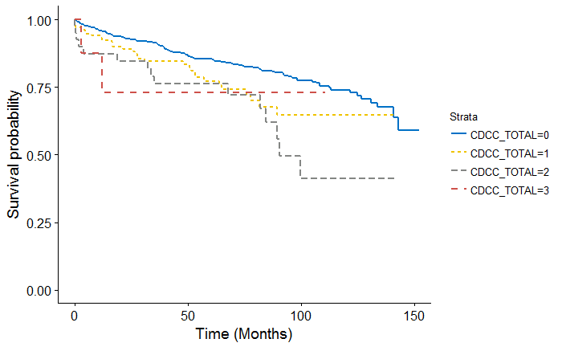

## Class (treatment at performing facility)

```
_________________________________________________

## CLASS_OF_CASE_F
_________________________________________________
Call: survfit(formula = Surv(DX_LASTCONTACT_DEATH_MONTHS, PUF_VITAL_STATUS ==
    0) ~ CLASS_OF_CASE_F, data = data)

                                  n events median 0.95LCL 0.95UCL
CLASS_OF_CASE_F=Other_Facility   53     11   89.3    67.2      NA
CLASS_OF_CASE_F=All_Part_Prim  1027    186     NA   142.9      NA

Call: survfit(formula = Surv(DX_LASTCONTACT_DEATH_MONTHS, PUF_VITAL_STATUS ==
    0) ~ CLASS_OF_CASE_F, data = data)

                CLASS_OF_CASE_F=Other_Facility
 time n.risk n.event survival std.err lower 95% CI upper 95% CI
   12     35       3    0.929  0.0395        0.855        1.000
   24     28       1    0.898  0.0488        0.808        0.999
   36     24       1    0.864  0.0579        0.757        0.985
   48     16       2    0.775  0.0790        0.635        0.946
   60     15       0    0.775  0.0790        0.635        0.946
  120      1       4    0.485  0.1302        0.286        0.821

                CLASS_OF_CASE_F=All_Part_Prim
 time n.risk n.event survival std.err lower 95% CI upper 95% CI
   12    936      49    0.951 0.00678        0.938        0.965
   24    841      29    0.921 0.00858        0.904        0.938
   36    700      19    0.899 0.00977        0.880        0.918
   48    593      23    0.868 0.01138        0.846        0.891
   60    485      17    0.842 0.01270        0.817        0.867
  120     92      42    0.721 0.02158        0.680        0.764





## Univariable Cox Proportional Hazard Model for:  CLASS_OF_CASE_F

Call:
coxph(formula = Surv(DX_LASTCONTACT_DEATH_MONTHS, PUF_VITAL_STATUS ==
    0) ~ CLASS_OF_CASE_F, data = data)

  n= 1080, number of events= 197

                                coef exp(coef) se(coef)     z Pr(>|z|)
CLASS_OF_CASE_FAll_Part_Prim -0.6097    0.5435   0.3111 -1.96     0.05 .
---
Signif. codes:  0 *** 0.001 ** 0.01 * 0.05 . 0.1   1

                             exp(coef) exp(-coef) lower .95 upper .95
CLASS_OF_CASE_FAll_Part_Prim    0.5435       1.84    0.2954         1

Concordance= 0.51  (se = 0.007 )
Rsquare= 0.003   (max possible= 0.903 )
Likelihood ratio test= 3.23  on 1 df,   p=0.07236
Wald test            = 3.84  on 1 df,   p=0.05002
Score (logrank) test = 3.96  on 1 df,   p=0.04656
```

```
Removed 1 rows containing missing values (geom_errorbar).
```

```
## Unadjusted Kaplan Meier Overall Survival Curve for:  CLASS_OF_CASE_F
```

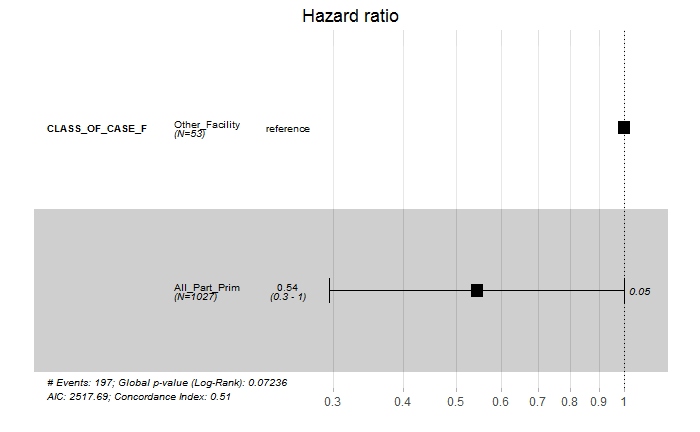

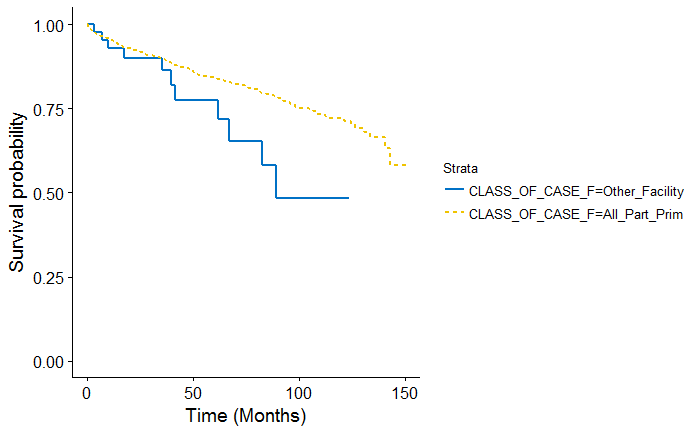

## Year

```
_________________________________________________

## YEAR_OF_DIAGNOSIS
_________________________________________________
Call: survfit(formula = Surv(DX_LASTCONTACT_DEATH_MONTHS, PUF_VITAL_STATUS ==
    0) ~ YEAR_OF_DIAGNOSIS, data = data)

                         n events median 0.95LCL 0.95UCL
YEAR_OF_DIAGNOSIS=2004  87     26     NA   142.9      NA
YEAR_OF_DIAGNOSIS=2005  84     22     NA      NA      NA
YEAR_OF_DIAGNOSIS=2006  94     19     NA   126.5      NA
YEAR_OF_DIAGNOSIS=2007  99     31     NA   113.1      NA
YEAR_OF_DIAGNOSIS=2008 107     24     NA      NA      NA
YEAR_OF_DIAGNOSIS=2009  91     16     NA    89.3      NA
YEAR_OF_DIAGNOSIS=2010  92     23     NA      NA      NA
YEAR_OF_DIAGNOSIS=2011  92      9     NA      NA      NA
YEAR_OF_DIAGNOSIS=2012  95     11     NA      NA      NA
YEAR_OF_DIAGNOSIS=2013 131     11     NA      NA      NA
YEAR_OF_DIAGNOSIS=2014 108      5     NA      NA      NA

Call: survfit(formula = Surv(DX_LASTCONTACT_DEATH_MONTHS, PUF_VITAL_STATUS ==
    0) ~ YEAR_OF_DIAGNOSIS, data = data)

                YEAR_OF_DIAGNOSIS=2004
 time n.risk n.event survival std.err lower 95% CI upper 95% CI
   12     80       4    0.953  0.0229        0.909        0.999
   24     75       3    0.917  0.0301        0.860        0.978
   36     70       4    0.867  0.0373        0.797        0.944
   48     66       2    0.842  0.0402        0.767        0.925
   60     65       1    0.830  0.0416        0.752        0.915
  120     41       8    0.720  0.0513        0.626        0.828

                YEAR_OF_DIAGNOSIS=2005
 time n.risk n.event survival std.err lower 95% CI upper 95% CI
   12     75       5    0.939  0.0266        0.888        0.992
   24     72       2    0.913  0.0313        0.854        0.977
   36     69       1    0.901  0.0334        0.838        0.968
   48     66       3    0.861  0.0388        0.789        0.941
   60     64       1    0.848  0.0404        0.773        0.931
  120     33       8    0.721  0.0541        0.623        0.835
```

[output cut: 98 more lines]

```
YEAR_OF_DIAGNOSIS2006    0.7909     1.2644    0.4293     1.457
YEAR_OF_DIAGNOSIS2007    1.4619     0.6841    0.8449     2.529
YEAR_OF_DIAGNOSIS2008    1.1312     0.8841    0.6306     2.029
YEAR_OF_DIAGNOSIS2009    1.0117     0.9884    0.5260     1.946
YEAR_OF_DIAGNOSIS2010    1.7369     0.5757    0.9539     3.163
YEAR_OF_DIAGNOSIS2011    0.7068     1.4149    0.3210     1.556
YEAR_OF_DIAGNOSIS2012    0.9726     1.0282    0.4633     2.041
YEAR_OF_DIAGNOSIS2013    0.9512     1.0514    0.4504     2.009
YEAR_OF_DIAGNOSIS2014    0.6422     1.5573    0.2378     1.734

Concordance= 0.574  (se = 0.022 )
Rsquare= 0.012   (max possible= 0.903 )
Likelihood ratio test= 12.93  on 10 df,   p=0.2278
Wald test            = 13.21  on 10 df,   p=0.2124
Score (logrank) test = 13.62  on 10 df,   p=0.1911
```

```
Removed 1 rows containing missing values (geom_errorbar).
```

```
## Unadjusted Kaplan Meier Overall Survival Curve for:  YEAR_OF_DIAGNOSIS
```

```
This manual palette can handle a maximum of 10 values. You have supplied 11.
```

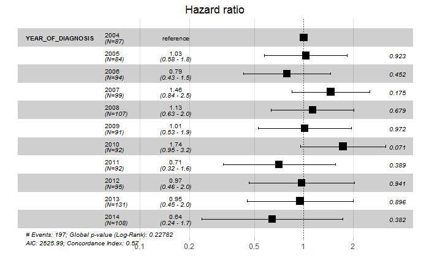

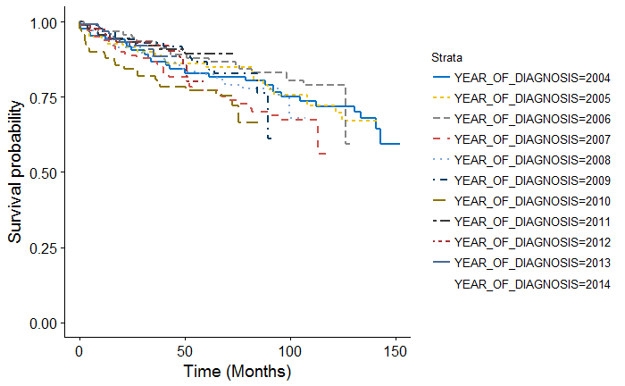